# Session 3: Bayesian mixed-effects model

Angeline Tsui

2021-04-06

This document is developed by Angeline Tsui, and all documents can be found [here](https://github.com/angelinetsui/srcd2021_bayesian.git).

# Introduction

This short tutorial covers some basic concepts of mixed-effect models and how to run Bayesian mixed-effect model in R.

## Learning goals

By the end of this class, you will have a basic understanding of the following:

- **A mixed-effect model**
- **The differences between fixed- and random-effect**
- **Running Bayesian mixed-effect model using brms in R**

# Quick overview: Regression

## What is a regression?

We often use a regression to model a relationship between the independent variable $IV_i$ and dependent variable $DV$. For example, a simple form of a linear regression model can be expressed using the following equation:

$$\text{DV} = \beta_0 + \beta_i{IV_i} + \epsilon$$
The $\beta_0$ is the intercept of the regression model, indicating the expected value of $DV$ when all $IV_i$ are zero. To understand the relationship between $DV$ and a particular $IV$, we can examine the regression coefficients: $\beta_i$. The $\beta_i$ indicates how $DV$ change when there is a one unit of change in $IV_i$. Thus, the $\beta_i$ indicates the strength and direction of the relationship between the $DV$ and $IV_i$.

Under the frequentist approach, we determine whether the relationship between the $DV$ and $IV_i$ is statistically significant and also use the regression model to make prediction of the $DV$ value based on specific amount of $IV_i$ values.

Typically regression models have several assumptions, they include:

1. Linearity between the $DV$ and $IV_i$
2. Residuals are uncorrelated with one another
3. Residuals have an expected value of zero
4. Variance of residuals is constant across $IV_i$, also known as homoscedasticity
5. No multicollinearity
6. (Optional) Residuals are normally distributed

In Developmental research, we often collect data repeatedly from one individual (e.g., one child) as we are interested in the development of the children’s ability over time. We cannot simply use regression models to analyze our data because we necessarily violate assumption 2: Residuals are uncorrelated with one another. In this case, we can use mixed-effect model to analyze this kind of data.

# Frequentist approach: Mixed-effect model

## What is a mixed-effect model?

Mixed-effect model is a statistical model that contains both fixed effects and random effects, and is widely used to model repeated measurements. Fixed effect are the typical $IV_i$ that we control for in a regression model, thus fixed effect are the population average effect of the $IV_i$ to the $DV$. To model the non-independence between DV within a repeated measure design, we can add random effects that capture the idiosyncratic individual differences between participants. Of course, random effects are not only bounded by the level of participants, but also can be bounded by the level of other grouping factors (e.g., laboratories). In general, random effects model the variations of the observations at the level of some grouping factors.

Let us take a look at the [ManyBabies 1 (MB1) dataset](https://github.com/manybabies/mb1-analysis-public.git) for an illustration of how mixed-effect model can help us model repeated measurement.

In MB1, we investigated whether monolingual infants across 67 laboratories show a preference for listening to infant-directed speech (baby talk; IDS) over adult-directed speech (ADS). In this experiment, we tested infants with 16 trials where half of the trials were in IDS and the other half were in ADS. Given that repeated measure design, the mixed-effect model is a ideal method to control for the random effects of individual infants’ preference for IDS over ADS. Furthermore, as we will see in the dataset, there are a lot of missing data as not all infants can complete all 16 trials. In traditional repeated ANOVA, we will either need to discard participants with missing data or use imputation method to fill out missing data. In contrast, we do not need to do that in a mixed-effect model as this model allows missing data by allocating less weight to participants with less data in the model.

MB1 data analysis

### Step 1: Packages

```r
library(lme4)
library(lmerTest)
library(tidyverse)
```

### Step 2: Data import and cleaning

In this analysis, let us only focus on the laboratories that used head-turn preference procedure (HPP) with North-American English speaking babies in the analysis for a simple illustration.

```r
mb1_data <- read_csv("https://raw.githubusercontent.com/manybabies/mb1-analysis-public/master/processed_data/03_data_trial_main.csv") %>%
            filter(method == "hpp",
                   nae) %>%  #only look at HPP data and nae infants
            drop_na(.) %>%
  mutate(age_group = factor(age_group,
                             levels = c("3-6 mo", "6-9 mo", "9-12 mo", "12-15 mo")), #fixing the order of age group
  trial_type = factor(trial_type,
                             levels = c("IDS", "ADS"))) #fixing the order of trial_type an d
```

### Step 3: Visualization

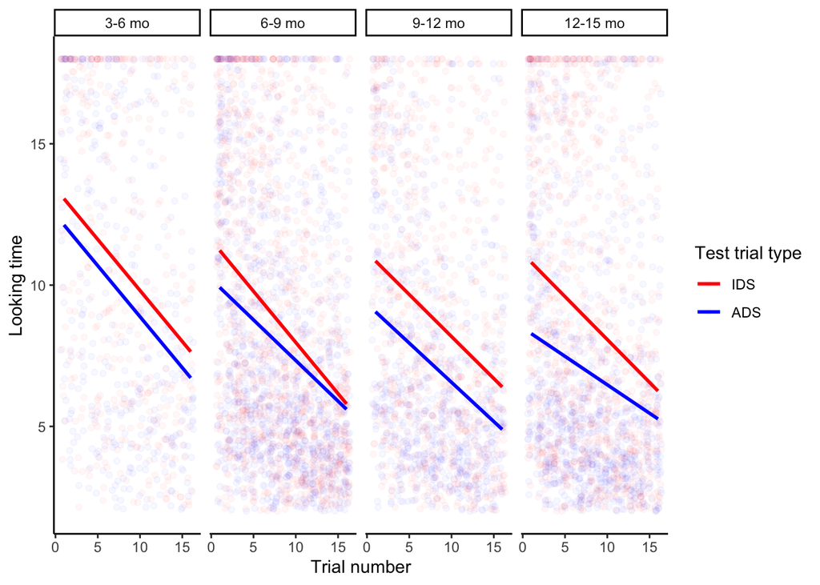

```r
ggplot(data = mb1_data, aes(x = trial_num, y = looking_time, color = trial_type)) +
  geom_point(alpha = 0.03, position = "jitter") +
  geom_smooth(method = "lm", se = FALSE) +
  facet_wrap(~age_group, ncol = 4, nrow = 1) +
  ylab("Looking time") +
  xlab("Trial number") +
  scale_color_manual(values = c("red", "blue")) +
  labs(color = "Test trial type") +
  theme_classic()
```

### Step 4: Analyzing the data

For simplicity, we focus on the random effects at the infant level (group) in this analysis. On the other hand, we will control for the interaction between age and IDS preference as a fixed effect.

In the following model, our DV is a log-transformed looking time following Csibra et al (2016) suggestion as well.

This is a much-simplified version of the model we used in MB1, just for purposes of this class.

$$\text{log looking time} = 1 +
\text{age * IDS} +
(1 | \text{infant})$$

First, let’s make a model using `lme4::lmer` to show how this would look.

```r
mb1_data <- mb1_data %>%
            mutate(center_age_mo = as.numeric(scale(age_mo, scale = FALSE)),
                   log_look_time = log(looking_time),
                   IDS = ifelse(trial_type == "IDS", 1, 0)) %>%
  drop_na(.)



Freq_model <- lmer(log_look_time ~ center_age_mo * IDS +
                     (1 |subid_unique),
                   data = mb1_data)

summary(Freq_model)$coefficients %>%
  knitr::kable(digits = 3)
```

|  | Estimate | Std. Error | df | t value | Pr(>\|t\|) |
| --- | --- | --- | --- | --- | --- |
| (Intercept) | 1.853 | 0.015 | 731.343 | 123.733 | 0 |
| center_age_mo | -0.035 | 0.005 | 746.421 | -6.950 | 0 |
| IDS | 0.158 | 0.013 | 6005.720 | 11.762 | 0 |
| center_age_mo:IDS | 0.021 | 0.004 | 6007.955 | 4.609 | 0 |

# Bayesian approach: Mixed-effect model

### Step 1: Packages

```r
library(brms)
library(tidybayes)
library(bayesplot)
library(rstanarm)
```

### Step 2: Data Analysis and visualization

```r
Bayes_model_default <- brm(looking_time ~ center_age_mo * IDS +
                     (1 |subid_unique),
                     family = lognormal(),
                     data = mb1_data,
                     # extra settings to make things go faster and to save data
                     warmup = 1000,
                     iter = 4000,
                     cores = 2,
                     chains = 2,
                     seed = 123,
                     save_pars = save_pars(all = T),
                     control = list(adapt_delta = 0.95),
                     file="mb1_bayes.mod")


print(summary(Bayes_model_default), digits = 3)
```

```
##  Family: lognormal
##   Links: mu = identity; sigma = identity
## Formula: looking_time ~ center_age_mo * IDS + (1 | subid_unique)
##    Data: mb1_data (Number of observations: 6464)
## Samples: 2 chains, each with iter = 4000; warmup = 1000; thin = 1;
##          total post-warmup samples = 6000
##
## Group-Level Effects:
## ~subid_unique (Number of levels: 483)
##               Estimate Est.Error l-95% CI u-95% CI  Rhat Bulk_ESS Tail_ESS
## sd(Intercept)    0.251     0.011    0.230    0.274 1.001     2030     3146
##
## Population-Level Effects:
##                   Estimate Est.Error l-95% CI u-95% CI  Rhat Bulk_ESS Tail_ESS
## Intercept            1.853     0.015    1.823    1.882 1.000     2547     3591
## center_age_mo       -0.035     0.005   -0.044   -0.025 1.000     2702     3476
## IDS                  0.158     0.014    0.132    0.184 1.000     8313     4472
## center_age_mo:IDS    0.021     0.005    0.012    0.029 1.000    11967     4542
##
## Family Specific Parameters:
##       Estimate Est.Error l-95% CI u-95% CI  Rhat Bulk_ESS Tail_ESS
## sigma    0.539     0.005    0.529    0.548 1.000     7887     4430
##
## Samples were drawn using sampling(NUTS). For each parameter, Bulk_ESS
## and Tail_ESS are effective sample size measures, and Rhat is the potential
## scale reduction factor on split chains (at convergence, Rhat = 1).
```

Let us visualize the posterior distribution of some parameters.

```r
posterior_default <- as.array(Bayes_model_default)
dim(posterior_default)
```

```
## [1] 3000    2  974
```

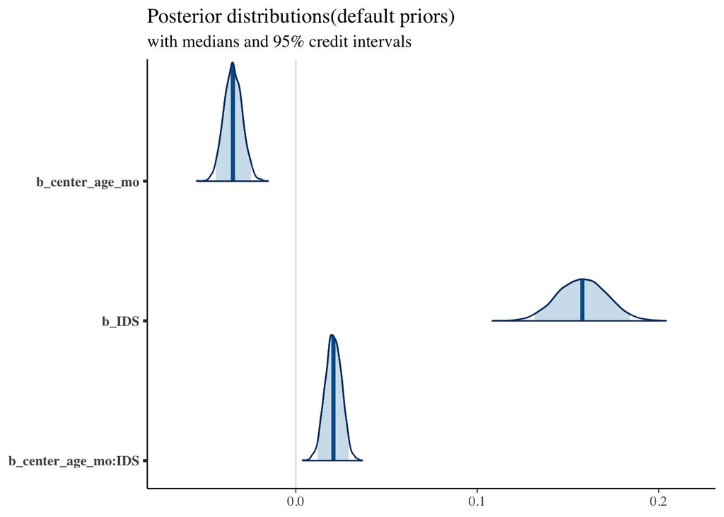

```r
#dimnames(posterior_default) finding the names of the parameters

post_pdf_default <- mcmc_areas(posterior_default,
           pars = c("b_center_age_mo",
                    "b_IDS",
                    "b_center_age_mo:IDS"), #you can select which parameter(s) you want to plot
           prob = 0.95) +
  ggtitle("Posterior distributions(default priors)",
          "with medians and 95% credit intervals")

post_pdf_default
```

Thus far, we did the Bayesian analysis using the default priors. But an important feature of Bayesian analysis is that we can incoporate our priors in our analysis.

### Step 3: Incoporate priors in our analyses

Let us take a look at how many prior parameters that we need to set up.

```r
get_prior(looking_time ~ center_age_mo * IDS, data = mb1_data)
```

```
##                   prior     class              coef group resp dpar nlpar bound
##                  (flat)         b
##                  (flat)         b     center_age_mo
##                  (flat)         b center_age_mo:IDS
##                  (flat)         b               IDS
##  student_t(3, 6.6, 4.4) Intercept
##    student_t(3, 0, 4.4)     sigma
##        source
##       default
##  (vectorized)
##  (vectorized)
##  (vectorized)
##       default
##       default
```

Set up priors like this

```r
priors <- c(prior(normal(2, 1), class = Intercept), #we expect mean looking time = 2sec as this is the min looking time for the experiment
            prior(normal(0, 0.5), class = b), #our main concern is modeling the interaction term, which we expect to be relatively small
            prior(normal(0, 1), class = sigma))
```

```r
Bayes_model_priors <- brm(looking_time ~ center_age_mo * IDS +
                     (1 |subid_unique),
                   family = lognormal(),
                   prior = priors,
                   data = mb1_data,
                   warmup = 1000,
                   iter = 4000,
                   cores = 2,
                   chains = 2,
                   seed = 456,
                   save_pars = save_pars(all = T),
                   control = list(adapt_delta = 0.95),
                   file="mb1_bayes_priors.mod")

print(summary(Bayes_model_priors), digits = 3)
```

```
##  Family: lognormal
##   Links: mu = identity; sigma = identity
## Formula: looking_time ~ center_age_mo * IDS + (1 | subid_unique)
##    Data: mb1_data (Number of observations: 6464)
## Samples: 2 chains, each with iter = 4000; warmup = 1000; thin = 1;
##          total post-warmup samples = 6000
##
## Group-Level Effects:
## ~subid_unique (Number of levels: 483)
##               Estimate Est.Error l-95% CI u-95% CI  Rhat Bulk_ESS Tail_ESS
## sd(Intercept)    0.251     0.011    0.231    0.274 1.000     2533     4190
##
## Population-Level Effects:
##                   Estimate Est.Error l-95% CI u-95% CI  Rhat Bulk_ESS Tail_ESS
## Intercept            1.854     0.015    1.824    1.882 1.001     2974     3987
## center_age_mo       -0.035     0.005   -0.045   -0.025 1.003     2549     3651
## IDS                  0.158     0.014    0.131    0.184 1.000    11257     4245
## center_age_mo:IDS    0.021     0.005    0.012    0.030 1.000    12142     4680
##
## Family Specific Parameters:
##       Estimate Est.Error l-95% CI u-95% CI  Rhat Bulk_ESS Tail_ESS
## sigma    0.539     0.005    0.529    0.548 1.000    10944     4367
##
## Samples were drawn using sampling(NUTS). For each parameter, Bulk_ESS
## and Tail_ESS are effective sample size measures, and Rhat is the potential
## scale reduction factor on split chains (at convergence, Rhat = 1).
```

Let us visualize the posterior distribution of some parameters after we have incorporated some prior information.

```r
posterior_priors <- as.array(Bayes_model_priors)
dim(posterior_priors)
```

```
## [1] 3000    2  974
```

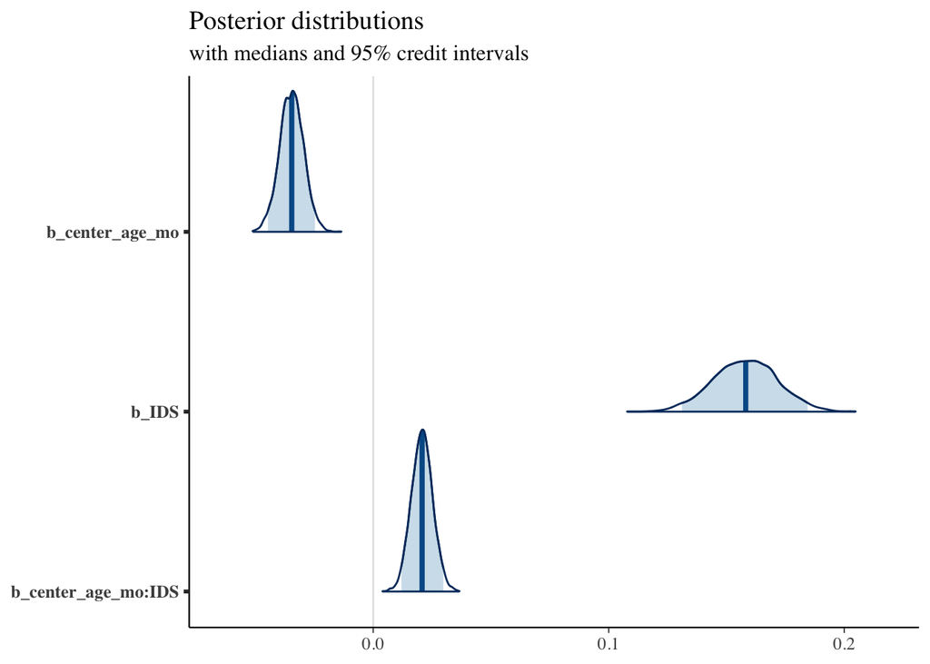

```r
#dimnames(posterior_priors) finding the names of the parameters

prior_post_pdf <- mcmc_areas(posterior_priors,
           pars = c("b_center_age_mo",
                    "b_IDS",
                    "b_center_age_mo:IDS"), #you can select which parameter(s) you want to plot
           prob = 0.95) +
  ggtitle("Posterior distributions",
          "with medians and 95% credit intervals")

prior_post_pdf
```

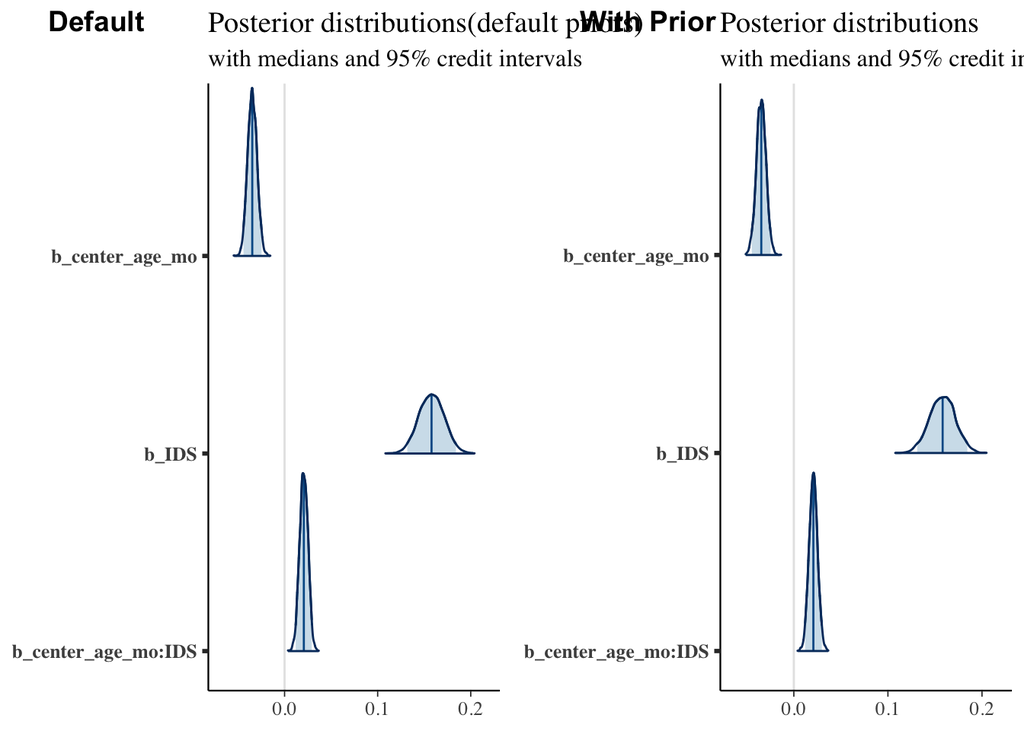

```r
cowplot::plot_grid(post_pdf_default, prior_post_pdf, labels = c("Default", "With Prior"))
```

## Step 4: Posterior predictive check

Posterior predictive check allows us to examine how well the model fits the data. It assesses the deviation between the data generated from the model and the actual data.

Let us look at the posterior predictive check for the default model:

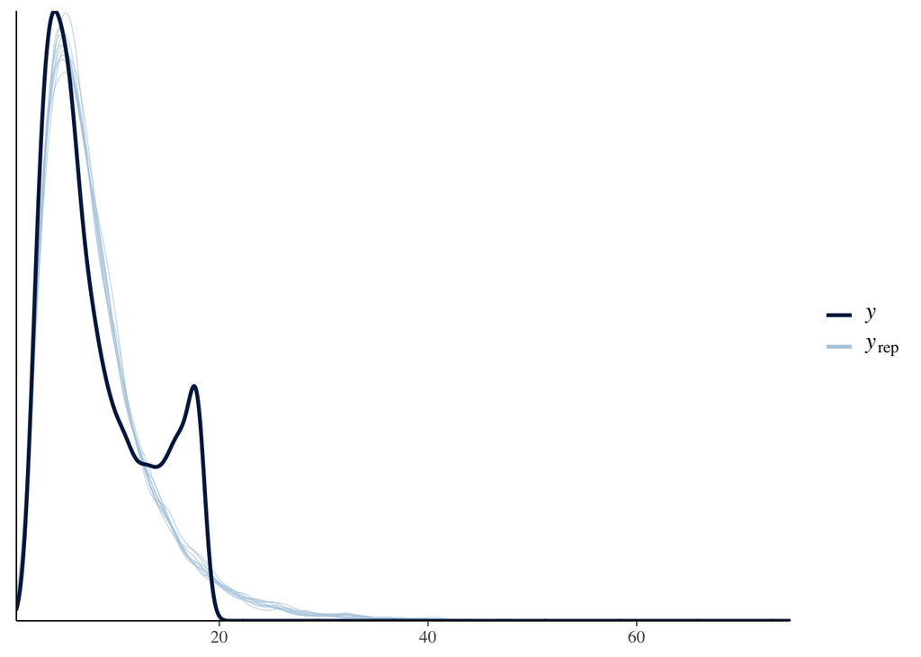

```r
pp_check_default <- pp_check(Bayes_model_default)
pp_check_default
```

This posterior predictive check highlights that there is a lot of censoring in our looking time distribution, which means that our model is describing some aspects of the distribution but not others. So this is an area for future improvement of our model.